# Joinpoint Regression Tutorial

Taylor P. van Doren

10/18/2021

### INTRODUCTION

This file will go through the process of joinpoint regression analysis using the **Joinpoint Regression Program**. Joinpoint Trend Analysis is a statistical software built by the National Cancer Institute of the National Institutes of health, Division of Cancer Control& Population Science. The program is completely open source and available for download at http://surveillance.cancer.gov/joinpoint. All you have to do is register for the software, and you will be sent a link with permission to download the program. It is perfect for researchers seeking to gain some insights into how rates change over time.

This file will introdue the data and get it ready to import into the joinpoint program, but the bulk of the analysis will not be performed within this R file. Most of the code here will be devoted to creating visualizations of the data and analyses performed outside the file in the Joinpoint Regression Program.

There is another file dedicated to logistic joinpoint analyses within this Github Repository. Each of these methods are useful, but they are different approaches, so use the one that serves you best.

### Load Libraries

```r
library(ggplot2)
```

### Load Data

This data is from the CDC National Center for Health Statistics National Vital Statistics System, the Age-Adjusted Death Rates for Selected Causes, Death Registration States, 1900-1932, and United States 1933-98.

*Link: https://www.cdc.gov/nchs/nvss/mortality/hist293.htm*

```r
mortdata <- read.csv("mortality data.csv")
head(mortdata)
```

```
##   year       cod  asdr
## 1 1900 Accidents  90.3
## 2 1901 Accidents 109.3
## 3 1902 Accidents  93.6
## 4 1903 Accidents 106.9
## 5 1904 Accidents 112.8
## 6 1905 Accidents 108.5
```

### Plot the initial data

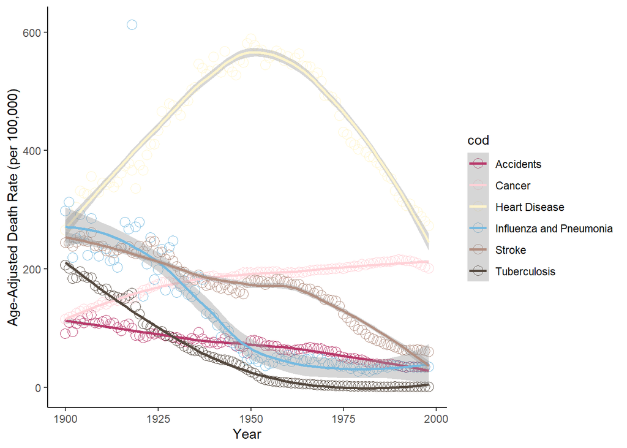

```r
ggplot(mortdata, aes(year, asdr, color = cod)) +
  geom_point(size = 3.5, shape = 1) +
  geom_smooth() +
  theme_classic() +
  xlab("Year") +
  ylab("Age-Adjusted Death Rate (per 100,000)") +
  tayloRswift::scale_color_taylor("lover")
```

Looking at the initial plot will really help us develop some intuition about the kinds of results we might hope to see from the regression analyses. Since this regression method identifies points ofsignificant change in rates over a time period, and there are some clear points here that we will be looking out for when we run the regression.

For example, it’s clear that there was a major increase and then decrease of mortality rates from heart disease during the 20th century, and it appears as if the turning point was somewhere during the 1950s. We should keep our eyes out for identified joinpoints in that decade.

The data are in the correct format for analyses in the joinpoint program, so we’ll head over there to get the data analyzed.

**SEE THE PDF OF THE INSTRUCTIONS ON HOW TO RUN THESE ANALYSES IN THE JOINPOINT REGRESSION SOFTWARE.**

After analyses, we’ll need to put together all the results and import them back to R so we can create some more appealing figures.